# Legea lui Benford

Stan Ana-Maria, Ionescu Alexandru, Haiducu Stefan

20/01/2022

## **Cateva informatii despre Legea lui Benford**

**Legea lui Benford** (legea primei cifre), este o observație conform căreia, în multe seturi de date numerice, prima cifră este probabil să fie mică. În seturile care respectă legea, numărul 1 apare ca prima cifră în aproximativ 30% din cazuri, probabilitate mult mai mare decât cea așteptată de 11.1% (una din nouă cifre) în timp ce 9 apare ca cifră principală în mai puțin de 5% din timp. Legea este numită după fizicianul Frank Benford, care a publicat-o în 1938 într-o lucrare intitulată „The Law of Anomalous Numbers”, deși a fost descoperită anterior de Simon Newcomb în 1881.

Un set de numere îndeplinește Legea lui Benford dacă probabilitatea ca prima cifră a unui număr să fie cifra d, d ≠ 0, este de:
$$P(d)= log{_{10}}{(\frac{d+1}{d})}$$

| d | P(d) |
| --- | --- |
| 1 | 30.1% |
| 2 | 17.6% |
| 3 | 12.5% |
| 4 | 9.7% |
| 5 | 7.9% |
| 6 | 6.7% |
| 7 | 5.8% |
| 8 | 5.1% |
| 9 | 4.6% |

P(d) este proportional cu distanța de la d la d + 1 pe o scară logaritmică. Prin urmare, aceasta este distribuția așteptată dacă logaritmii numerelor sunt distribuiți uniform și aleatoriu. Spre exemplu, un număr x, cuprins între 1 și 10 are prima cifră 1 dacă $1 \le x < 2$, și începe cu cifra 9 dacă $9 \le x < 10$. Analog, x începe cu cifra 1 dacă $\log(1) \le \log(x) < \log(2)$, sau are ca prima cifră 9 dacă $\log(9) \le \log(x) < \log(10)$. Cum intervalul $[\log(1), \log(2)]$ este mult mai mare decât intervalul $[\log(9), \log(10)]$ (0.30, respectiv 0.05), dacă $\log(x)$ este distribuit uniform și aleatoriu, este mult mai probabil ca acesta să se afle în intervalul mai mare decât în intervalul mai mic, adică este mult mai probabil ca numărul să înceapă cu cifra 1 decât cu cifra 9. Probabilitățile sunt proporționale cu capetele intervalului, dând ecuația de mai sus.

Este posibil să se extindă legea la cifre dincolo de prima. În special, pentru orice număr dat de cifre, probabilitatea de a întâlni un număr care începe cu șirul de cifre n de acea lungime, eliminând zerourile de la început, este dată de $log{_{10}}{(\frac{n+1}{n})}$.

Spre exemplu, probabilitatea ca un număr să înceapă cu cifrele 2, 5 și 7 (în această ordine) este de $log{_{10}}{(\frac{258}{257})≈0.0016865}$. Câteva numere care satisfac această condiție sunt: 25.789, 0.0025749, 25764388.

- Unele șiruri infinite de numere întregi satisfac Legea lui Benford. Printre acestea se numără:
  - Șirul lui Fibonacci
  - Numerele factoriale
  - Puterile lui 2
- Lucruri de luat în considerare atunci când se aplică Legea lui Benford:
  - Legea lui Benford funcționează mai bine cu seturi mai mari de date.
  - Pentru a se conforma legii, setul de date utilizat trebuie să conțină date în care fiecare cifră are șanse egale de a fi prima cifră. În caz contrar, legea lui Benford nu se aplică.
  - Legea lui Benford nu poate dovedi în mod definitiv prezența sau absența numerelor autentice.

## **Prezentarea codului**

Această bucată de cod este pentru afișarea in shiny, creează un panou în care adăugăm, unul sub altul, input-ul pentru câte numere se generează și graficul rezultat în urma execuției programului, fiind primit de la output-ul funcției care construiește graficul:

```r
mainPanel(
  numericInput(
    inputId = "nr",
    label = "Lungimea listei de numere aleatorii:",
    value = 1000,
    min = 100,
    max = 10000,
    width = 300
  ),
  plotOutput(outputId = "distPlot")
  )
```

Definim graficul care va fi trimis pe panoul principal pentru afișare:

```r
output$distPlot <- renderPlot({
```

Definim funcția care calculează probabilitatea conform formulei din Legea lui Benford, pentru numere în baza 10, deci care au prima cifră oricare dintre numerele din intervalul 1,9. Folosind acestea, creăm un barplot pe care evidențiem rezultatele calculului conform acestei formule.

```r
benfordslaw <- function(d) log10(1 + 1 / d)
digits <- 1:9
      BenfordsBarplot <- barplot(benfordslaw(digits), names.arg = digits, xlab = "Prima cifra a numarului",
                             ylim = c(0, .4), ylab="%",col=c("#1400ad"))
```

Rezultatul executiei codului este urmatorul grafic:

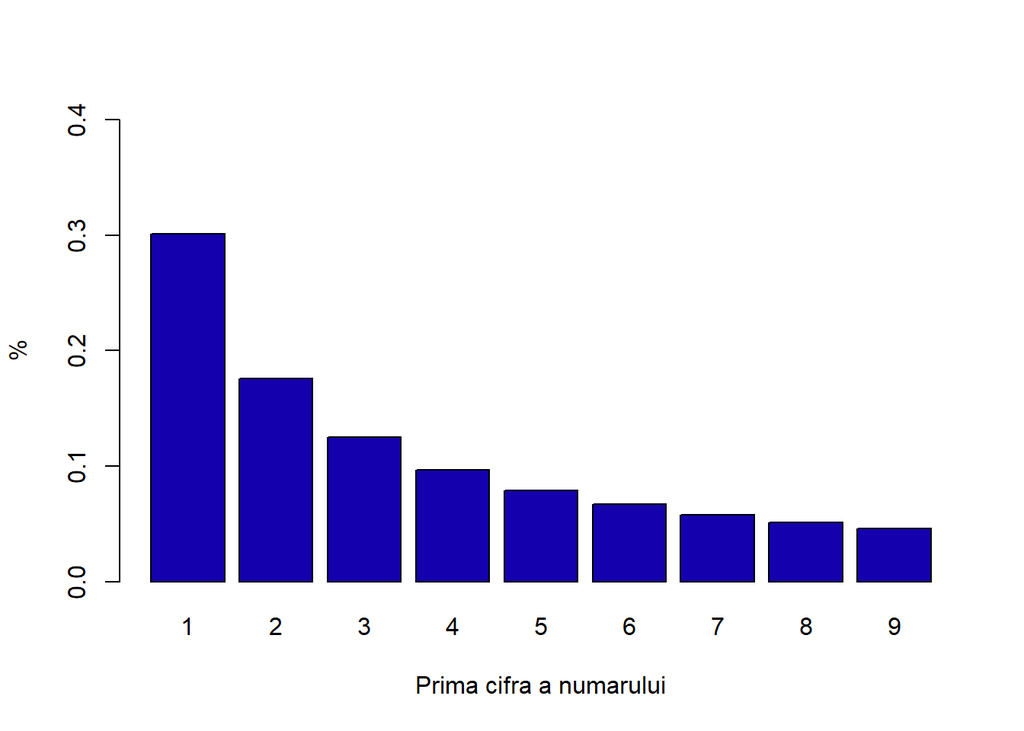

Funcția FirstDigit păstrează doar prima cifră din fiecare număr din listă, alegând primul caracter din reprezentarea numarului ca șir de caractere, și returnează lista modificată, FirstDigitPercent calculează procentul de apariție al fiecărei cifre, creând un tabel pentru fiecare cifră și împărțind numărul de elemente din tabel cu numărul total de elemente. Aceste procente de apariție sunt puse într-un data frame. InitDataFrame creează un data frame cu toate cifrele primite și frecvența 0 pentru toate.

```r
FirstDigit <- function(x) substr(gsub('[0.]', '', x), 1, 1)

FirstDigitPercent <- function(x) data.frame(table(FirstDigit(x)) / length(x))

InitDataFrame <- function(x) data.frame("Var1" = FirstDigit(x),"Freq" = 0)
```

Funcția DataFrameFreq folosește funcțiile declarate mai devreme pentru a crea un data frame care conține frecvența aparițiilor pentru toate cifrele din digits, întrucât pentru o listă cu puține numere, există posibilitatea să nu se genereze numere astfel încât să apară fiecare cifră cel puțin odată, astfel că parcurgem data frame-ul inițializat cu frecvența 0 la toate cifrele si modificăm frecvența aparițiilor acolo unde este nevoie. Totuși, o listă cu foarte puține numere nu ilustrează foarte bine legea, iar în unele cazuri legea lui Benford nu se aplică pe un șir prea mic.

```r
DataFrameFreq <- function(x) {
  DataFrame1<-FirstDigitPercent(x)
  DataFrame<-InitDataFrame(digits)
  j=1
  for(i in DataFrame1$Var1)
  {
   DataFrame[i,2]=DataFrame1[j,2]
   j=j+1
  }
   return (DataFrame)
}
```

Inserăm în variabila N lungimea listei generate (în exemplele următoare N va fi 1000), setăm seed-ul, ca rezultatele să nu difere, și generăm N numere între 0 și 100, iar frecvența acestora este pusă într-un data frame folosind funcția DataFrameFreq() de mai devreme. Folosind această frecvență a apariției cifrelor, trasăm pe graficul de mai devreme o linie care evidențiază procentul de apariție al cifrelor.

```r
N <- input$nr
set.seed(1234)
x1 <- runif(N, 0, 100)
DataFrame1 <- DataFrameFreq(x1)
lines(x = BenfordsBarplot[,1], y = DataFrame1$Freq, col = "#444e86", lwd = 3,
            type = "o", pch = 23, cex = 1, bg = "#444e86")
```

Rezultatul dupa executia codului de pana acum; se observă că nu există concordanță cu legea lui Benford momentan:

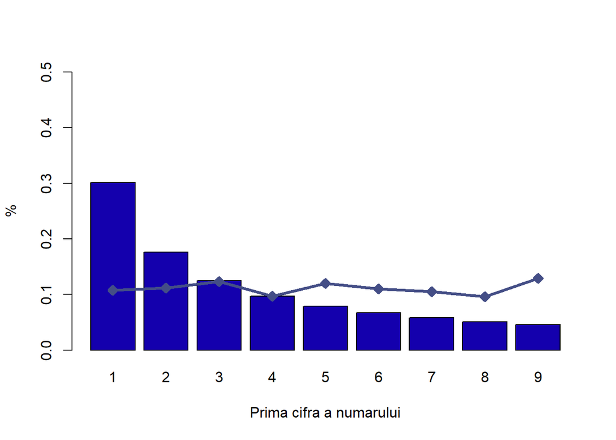

```r
DataFrame2 <- DataFrameFreq(x1^1.2)
lines(x = BenfordsBarplot[,1], y = DataFrame2$Freq, col = "#955196", lwd = 3,
            type = "o", pch = 23, cex = 1, bg = "#955196")
```

Se observă o mică îmbunătățire în concordanță:

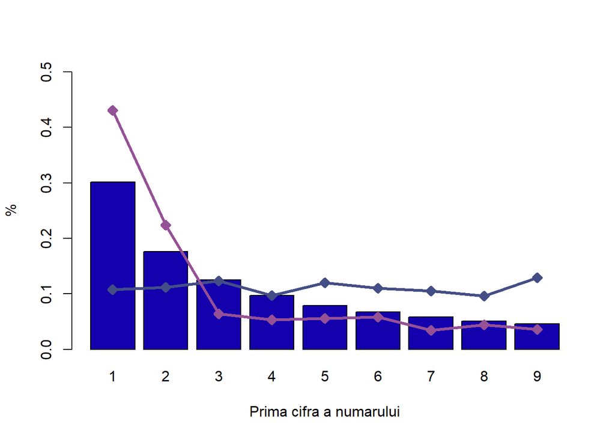

Generăm încă 1000 de valori aleatorii și afișăm linia:

```r
x3 <- runif(N, 0, 100)
DataFrame3 <- DataFrameFreq(x1^1.2 / x3)
lines(x = BenfordsBarplot[,1], y = DataFrame3$Freq, col = "#dd5182", lwd = 3,
            type = "o", pch = 23, cex = 1, bg = "#dd5182")
```

Acest rezultat se apropie foarte mult de ceea ce doream:

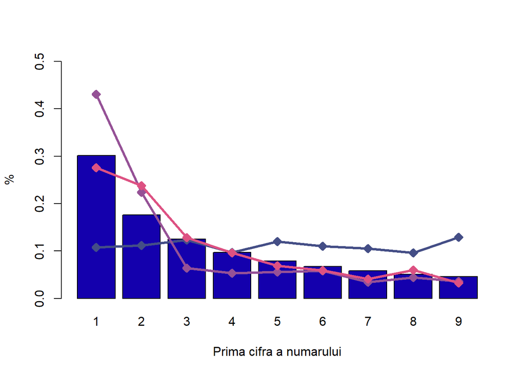

```r
x4 <- runif(N, 0, 100)
DataFrame4 <- DataFrameFreq(x1* x4)
lines(x = BenfordsBarplot[,1], y = DataFrame4$Freq, col = "#ff6e54", lwd = 3,
            type = "o", pch = 23, cex = 1, bg = "#ff6e54")
```

Acest rezultat se apropie foarte mult de ceea ce doream:

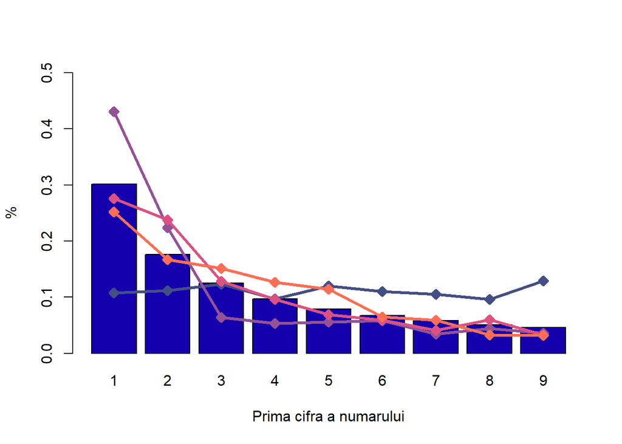

Adăugăm și o legendă pentru o înțelegere mai ușoară:

```r
legend("topright",title = "Rezultatul functiilor", legend=c("X1", "X1^1.2", "X1/X3", "X1*X4"),
col=c("#444e86", "#955196", "#dd5182", "#ff6e54","#ffa600"), lty=1:1, cex=1, lwd = 4.0)
```

[figure not shown]

```r
N <- 1000
```

```
      benfordslaw <- function(d) log10(1 + 1 / d)
digits <- 1:9
      BenfordsBarplot <- barplot(benfordslaw(digits), names.arg = digits, xlab = "Prima cifra a numarului",
                             ylim = c(0, .5), ylab="%",col=c("#1400ad"))
      N <- 1000
set.seed(1234)
x1 <- runif(N, 0, 100)

FirstDigit <- function(x) substr(gsub('[0.]', '', x), 1, 1)
FirstDigitPercent <- function(x) data.frame(table(FirstDigit(x)) / length(x))
InitDataFrame <- function(x) data.frame("Var1" = FirstDigit(x),"Freq" = 0)

DataFrameFreq <- function(x) {
  DataFrame1<-FirstDigitPercent(x)
  DataFrame<-InitDataFrame(digits)
  j=1
  for(i in DataFrame1$Var1)
  {
   DataFrame[i,2]=DataFrame1[j,2]
   j=j+1
  }
   return (DataFrame)
}

DataFrame1 <- DataFrameFreq(x1)
lines(x = BenfordsBarplot[,1], y = DataFrame1$Freq, col = "#444e86", lwd = 3,
            type = "o", pch = 23, cex = 1, bg = "#444e86")
DataFrame2 <- DataFrameFreq(x1^1.2)
lines(x = BenfordsBarplot[,1], y = DataFrame2$Freq, col = "#955196", lwd = 3,
            type = "o", pch = 23, cex = 1, bg = "#955196")
x3 <- runif(N, 0, 100)
DataFrame3 <- DataFrameFreq(x1^1.2 / x3)
lines(x = BenfordsBarplot[,1], y = DataFrame3$Freq, col = "#dd5182", lwd = 3,
            type = "o", pch = 23, cex = 1, bg = "#dd5182")
x4 <- runif(N, 0, 100)
DataFrame4 <- DataFrameFreq(x1 * x4)
lines(x = BenfordsBarplot[,1], y = DataFrame4$Freq, col = "#ff6e54", lwd = 3,
            type = "o", pch = 23, cex = 1, bg = "#ff6e54")

legend("topright",title = "Rezultatul functiilor", legend=c("X1", "X1^1.2", "X1^1.2/X3", "X1*X4"),
col=c("#444e86", "#955196", "#dd5182", "#ff6e54","#ffa600"), lty=1:1, cex=1, lwd = 4.0)
```

## Simulări

### Pentru 1000 de numere și diferite funcții

```r
N <- 1000
```

##### Graficul rezultat pentru primul șir generat(x1):

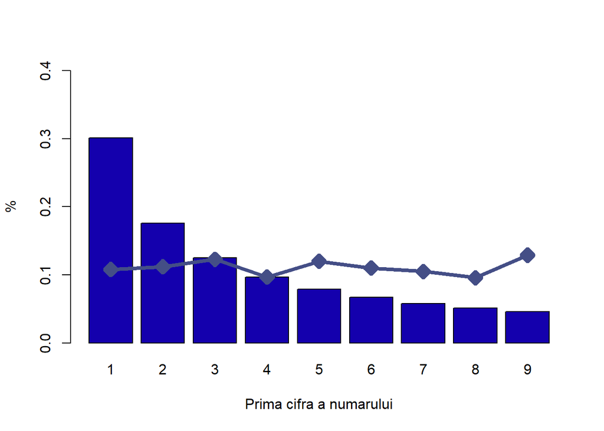

##### Rezultatul final:

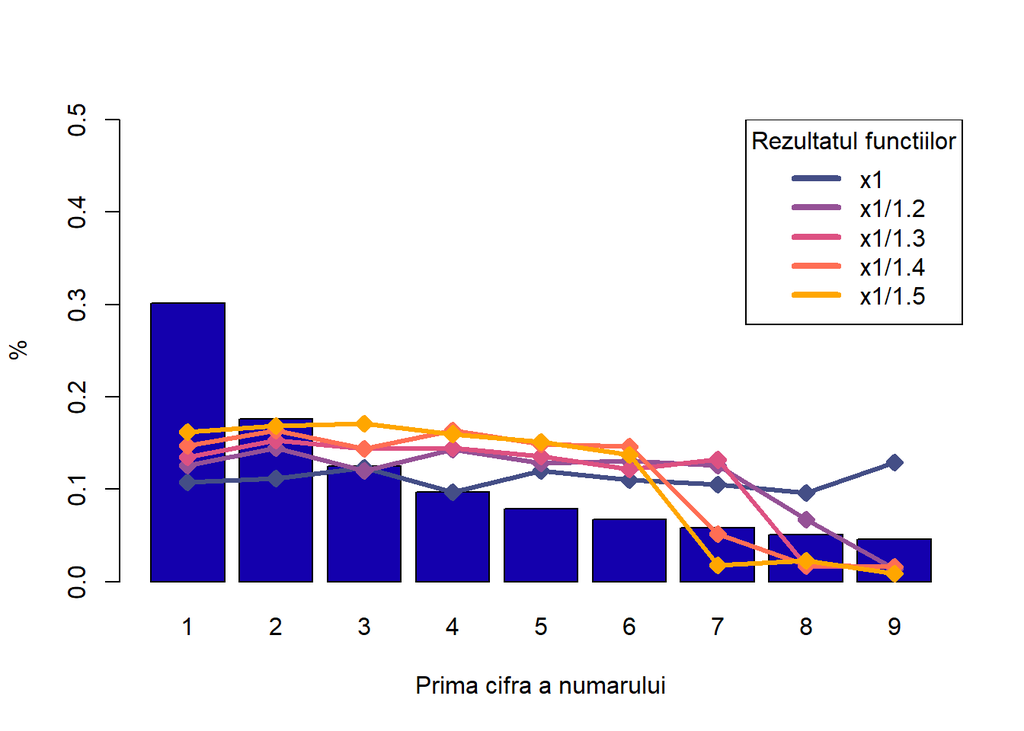

##### Rezultatul final:

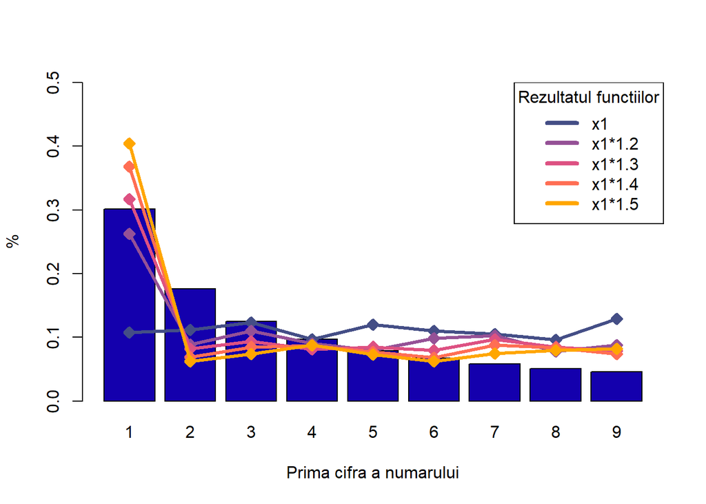

##### Rezultatul pentru șirul x1 când alegem cele mai mari 58 de structuri ale lumii:

În șirul x1 au fost introduse valori conform listei: https://en.wikipedia.org/wiki/List_of_tallest_buildings_and_structures#Tallest_structure_by_category

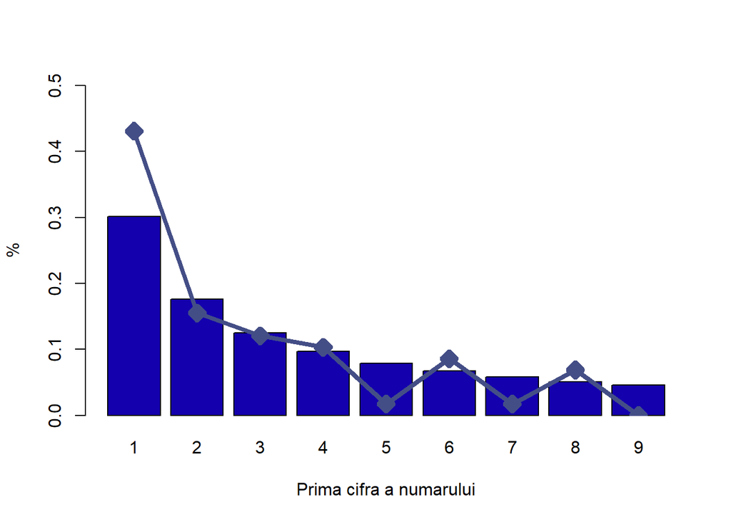

##### Rezultatul final:

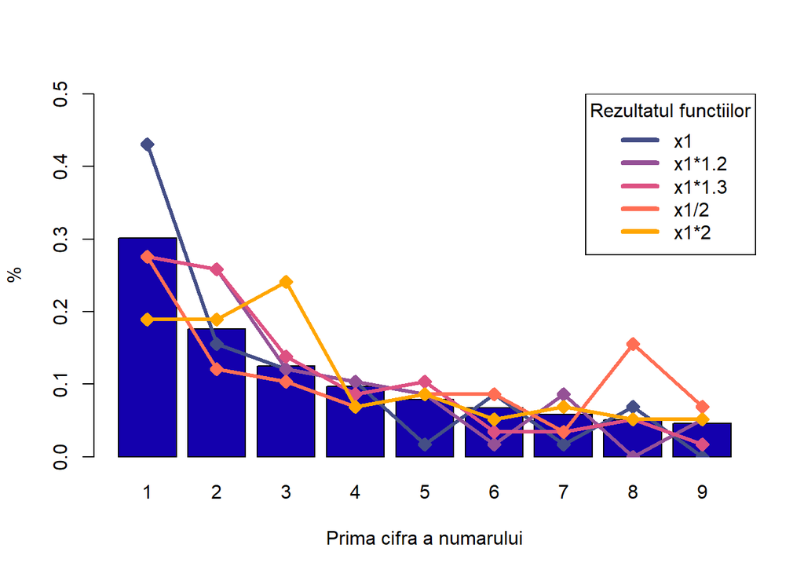

##### În exemplul următor vom inițializa șirul x1 cu primele 100 de numere din șirul lui Fibonacci și vom afișa graficul:

Inițializăm 2 variabile cu valoarea 1. Generăm o listă cu numerele din șirul lui Fibonacci, adunând ultimele 2 elemente precedente, pe baza formulei $n_2 = n_1 + n_0$

```r
N <- 100
nterms = N

n1 = 1
n2 = 1
count = 2

if(nterms == 1) {
  fibo <- list(n1)
}else {
  fibo <- list(n1, n2)
  while(count < nterms) {
    nth = n1 + n2
    fibo <- c(fibo, nth)

    n1 = n2
    n2 = nth
    count = count + 1
  }
}
```

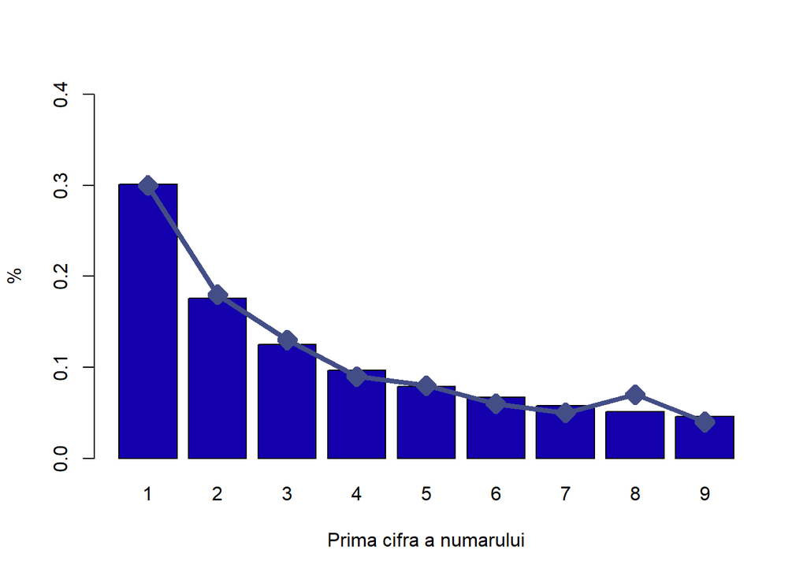

##### Rezultatul final:

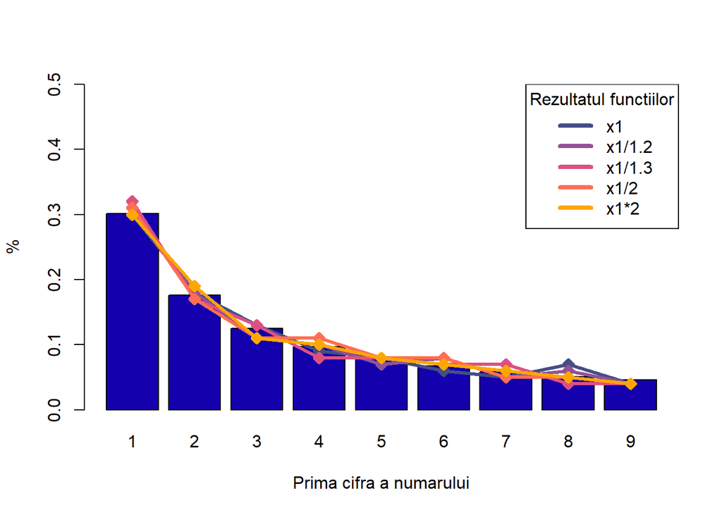

##### Inițializăm șirul x1 cu factorialul numerelor de la 1 la 100 și afișăm graficul:

Generăm un șir în care introducem factorialul fiecărui număr de la 1 la N, factorialul unui număr x fiind produsul tuturor numerelor de la 1 la x:

```r
N <- 100
nterms = N

n=1
count=1
fact <- c(n)
while(count<nterms){
  count = count + 1
  n = n * count
  fact <- c(fact,n)
}
```

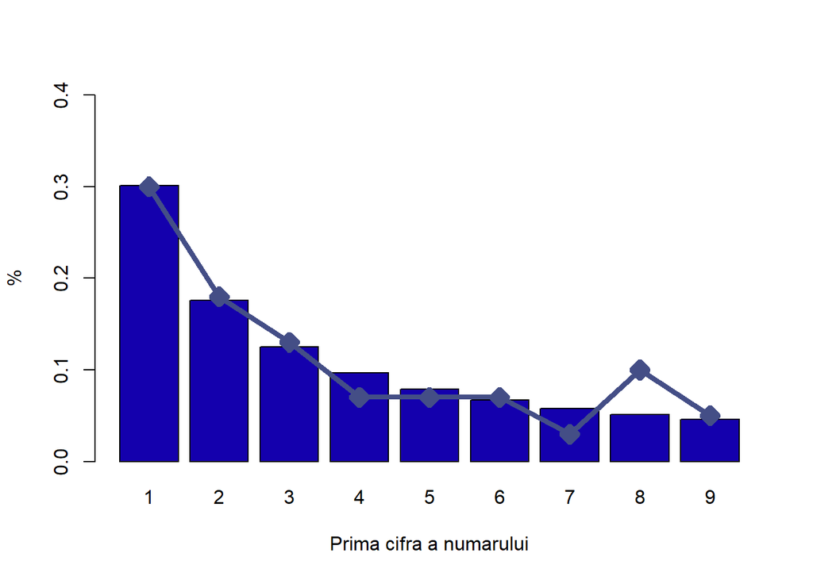

##### Rezultatul final:

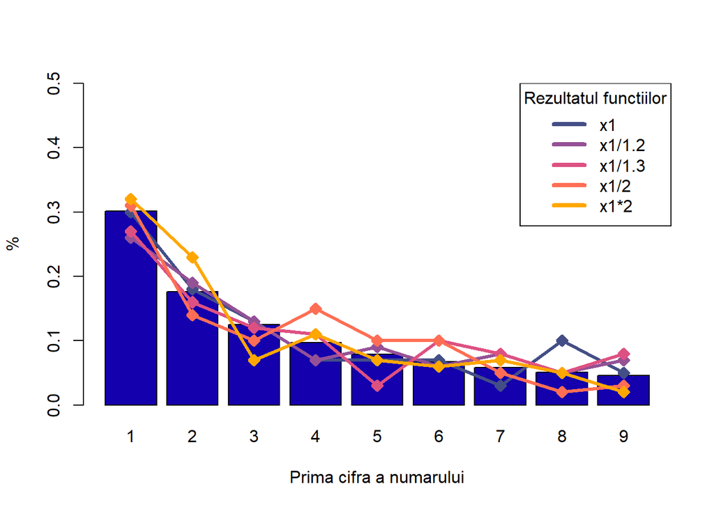

##### Inițializăm șirul x1 cu puterile lui 2 de la 1 la 100 și afișăm graficul:

Generăm un șir în care introducem toate puterile lui 2 de la 1 la N. Inițializăm o variabilă cu 1, introducem în șir numărul și apoi înmulțim numărul cu 2, repetând de N ori.

```r
N <- 100
nterms = N

n=1
count=0
pow <- c(n)
while(count<nterms){
  n = n * 2
  pow <- c(pow,n)
  count = count + 1
}
```

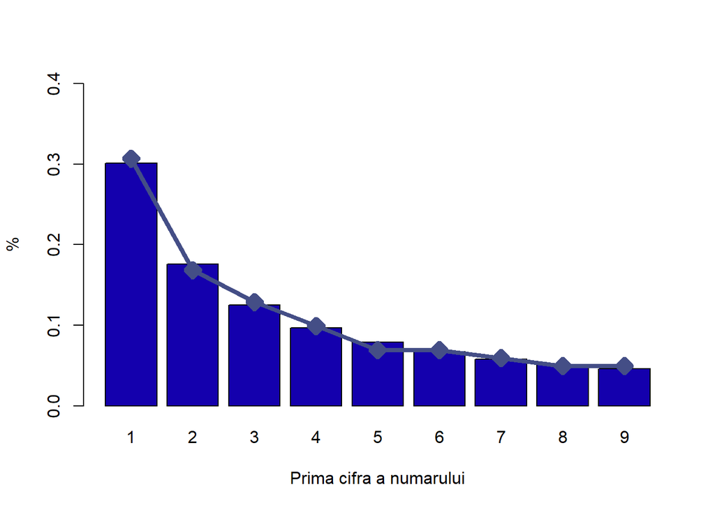

##### Rezultatul final:

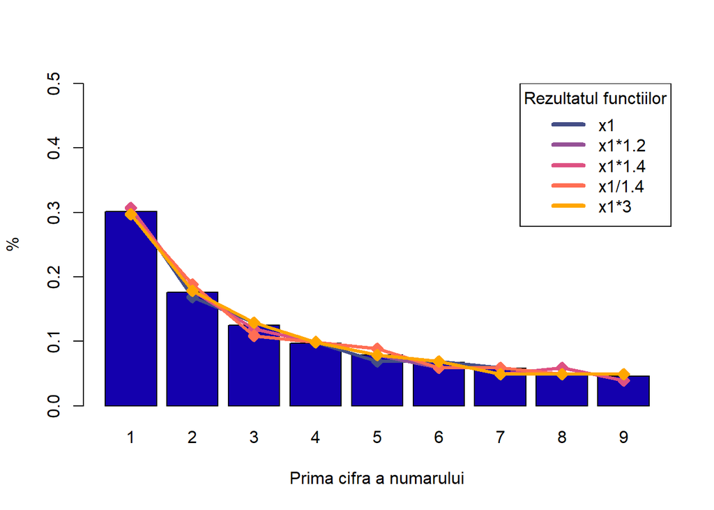